# ENG

# Atlantic Blue Shark Management Strategy Evaluation

## (*Prionace glauca*)

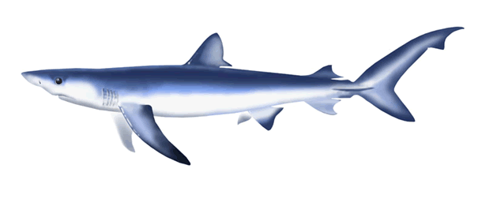

# Overview

## While a formal MSE process has not yet been launched for Blue Shark, several ICCAT recommendations call for the evaluation of feasibility: Rec. 21-09: Requests the SCRS to explore the feasibility of developing an MSE for Blue Shark. Rec. 22-08: Reiterates this request and establishes the basis for analytical development.

# Summary

## The SCRS has advanced the outlook for Blue Shark MSE through two key documents prepared in 2024. These focus on developing code architecture, conducting preliminary closed-loop simulations for the northern stock, and assessing technical feasibility. Taylor (2024) presents a compact closed-loop simulation framework for Blue Shark MSE that uses multivariate Bayesian priors for life-history parameters and tests ICCAT-relevant management procedures (MPs) against minimum performance standards. Example simulations show that several MPs—both index- and model-based—achieve high probabilities (>90%) of remaining above 40% BMSY, with green quadrant probabilities ranging from 60% to 90%, and greater catch variability observed in model-based MPs. Carruthers (2024) introduces a streamlined simulation platform for Atlantic Blue Shark MSE, using operating models that incorporate uncertainty in life-history and productivity parameters. It evaluates both index- and model-based MPs, demonstrating that many exceed performance benchmarks such as maintaining biomass above 40% BMSY and achieving 60–90% probability of being in the Kobe green quadrant. The platform also explores algorithms to automatically tune MPs to minimum performance standards. The full source code is available at github.com/Blue-Matter/Blue_Shark_MSE. The SCRS has submitted a feasibility analysis for northern and southern Blue Shark MSE to the Commission in 2025. Taylor et al (2025) presents an evaluation of the feasibility, cost, and timeline of conducting Management Strategy Evaluation (MSE) processes for the northern and southern Atlantic blue shark (BSH) stocks, following ICCAT Recommendations 23-10 and 23-11. The study builds on the 2023 stock assessment and prior simulation work, proposing a shared modeling framework using stock-specific operating models and management procedures (MPs). Two implementation options are examined: a two-year process with MP adoption by 2027, and a three-year process with adoption by 2028. The report concludes that MSE development for both BSH stocks is technically feasible, cost-effective, and consistent with ICCAT’s existing MSE framework, provided timely support, scientific coordination, and funding are secured.

# References